# project

## Cleaning

First, we need to clean up the dataset a bit.

```r
library(dplyr)
library(tidyr)

airbnb = read.csv("airbnb.csv")
str(airbnb)
```

```
## 'data.frame':    500 obs. of  63 variables:
##  $ id                         : int  14843458 722570 8153968 18327990 12673204 10344726 5737004 16826474 5414283 8610501 ...
##  $ listing_url                : Factor w/ 500 levels "https://www.airbnb.com/rooms/10043106",..: 131 431 453 316 56 4 391 243 381 464 ...
##  $ name                       : Factor w/ 500 levels "#61  King Arthurs Court",..: 177 302 191 410 119 124 151 193 179 17 ...
##  $ summary                    : Factor w/ 492 levels "","- Townhome 150 yds (2 min walk) from McCormick Place - Free Parking - Huge Room with queen bed (and futon) - Pr"| __truncated__,..: 124 1 283 421 463 126 280 292 323 175 ...
##  $ space                      : Factor w/ 366 levels "","- This is a great, two bedroom, one bathroom home on the 1st floor of a four unit building. The first bedroom h"| __truncated__,..: 250 78 349 1 176 107 170 6 365 51 ...
##  $ description                : Factor w/ 499 levels "- Townhome 150 yds (2 min walk) from McCormick Place - Free Parking - Huge Room with queen bed (and futon) - Pr"| __truncated__,..: 127 117 286 427 470 129 283 295 326 178 ...
##  $ neighborhood_overview      : Factor w/ 331 levels "","------------------------------------------------------------------------------ SUPER CONVENIENT LOCATION!!! ---"| __truncated__,..: 102 1 119 1 86 186 187 3 82 220 ...
##  $ notes                      : Factor w/ 225 levels "","- Any short-term stays of 3 or lesser nights (over a weekend) may be assessed a surcharge",..: 100 1 211 1 143 92 1 3 73 1 ...
##  $ transit                    : Factor w/ 346 levels "","- 1 min walk to the Lawrence Red Line station - 1 mile from Metra station (commuter rail) - Divvy Bike station "| __truncated__,..: 227 1 269 1 59 100 300 9 131 252 ...
##  $ access                     : Factor w/ 315 levels "","#94 is the door code. How to receive keys will be arranged ahead of time.",..: 194 1 312 1 163 297 1 52 172 22 ...
##  $ interaction                : Factor w/ 313 levels "","24/7 access to the host via phone, text, or email.",..: 301 1 300 1 121 178 1 223 103 198 ...
##  $ house_rules                : Factor w/ 318 levels "","-- Not handicap accessible (there are 59 stairs - no elevator!)",..: 107 151 41 225 98 176 267 236 55 143 ...
##  $ host_id                    : int  20653807 3731751 16500117 6903096 34473759 45766549 29751294 111964625 2768284 37417772 ...
##  $ host_url                   : Factor w/ 461 levels "https://www.airbnb.com/users/show/100027760",..: 106 205 82 369 185 264 156 33 143 206 ...
```

[output cut: 49 more lines]

```r
# Setting descriptions, URLS, to character types
airbnb_char = airbnb %>% mutate_at(c(2:12, 14, 18, 25), as.character)

# Set numerics where they're needed
library(stringr)
airbnb_char$host_response_rate = as.numeric(str_remove(airbnb_char$host_response_rate, "%"))
# all others should be properly formatted

# Set boolean columns
airbnb_char = airbnb_char %>% mutate_at(c(20, 23, 24, 29, 52, 55:62), as.character) # R won't reassign unless column is of character type
airbnb_char[airbnb_char=="f"] = "false" # true and false are parseable by as.logical
airbnb_char[airbnb_char=="No"] = "false"
airbnb_char[airbnb_char=="t"] = "true"
airbnb_char[airbnb_char=="Yes"] = "false"
airbnb_clean = airbnb_char %>% mutate_at(c(20, 23, 24, 29, 52, 55:62), as.logical)
# boolean values are set to be TRUE and FALSE

# Set missing values to NA
airbnb_clean[airbnb_clean==""] = NA # Note: this should work for both character and factor variables

# Setting dates to date types
airbnb_clean$host_since = as.Date(airbnb_clean$host_since, format="%m/%d/%Y")
# this is done last because it breaks slicing
```

## Initial EDA

Now, we can start with some exploration of individual variables.

```r
library(ggplot2)
```

First off, we’ll look at distributions of some simple numerical variables.

```r
# While there are many libraries for this, we can easily whip up a quick summary statistics function
summary_stats = function(variable) {
  cat("Total Count: ", length(variable), "\n")
  cat("N: ", sum(!is.na(variable)), "\n")
  cat("Minimum: ", min(variable, na.rm = TRUE), "\n")
  cat("Maximum: ", max(variable, na.rm = TRUE), "\n")
  cat("Mean: ", mean(variable, na.rm = TRUE), "\n")
  cat("Standard Deviation: ", sd(variable, na.rm = TRUE), "\n")
  cat("Median: ", median(variable, na.rm = TRUE), "\n")
  cat("Quantiles:", "\n")
  print(quantile(as.numeric(variable), c(0, 0.25, 0.5, 0.75, 1), na.rm = TRUE))
  cat("IQR: ", IQR(variable, na.rm = TRUE), "\n")
}
```

Host response rate:

```r
summary_stats(airbnb_clean$host_response_rate)
```

```
## Total Count:  500
## N:  480
## Minimum:  0
## Maximum:  100
## Mean:  96.23125
## Standard Deviation:  10.81784
## Median:  100
## Quantiles:
##   0%  25%  50%  75% 100%
##    0  100  100  100  100
## IQR:  0
```

Given that we have a median equal to our maximum, 100, along with such a high mean and low IQR, we clearly have a majority of hosts having a 100% response rate.

Number of guests accommodated:

```r
summary_stats(airbnb_clean$accommodates)
```

```
## Total Count:  500
## N:  500
## Minimum:  1
## Maximum:  16
## Mean:  3.872
## Standard Deviation:  2.600219
## Median:  3
## Quantiles:
##   0%  25%  50%  75% 100%
##    1    2    3    5   16
## IQR:  3
```

Price:

```r
summary_stats(airbnb_clean$price)
```

```
## Total Count:  500
## N:  500
## Minimum:  10
## Maximum:  950
## Mean:  135.416
## Standard Deviation:  125.9147
## Median:  100
## Quantiles:
##   0%  25%  50%  75% 100%
##   10   60  100  155  950
## IQR:  95
```

We will get four price categories based on our quantiles, which we’ll call very high, high, medium, and low, for later categorization use.

```r
low = quantile(airbnb_clean$price)[2]
medium = quantile(airbnb_clean$price)[3]
high = quantile(airbnb_clean$price)[4]

price_category = vector(length = length(airbnb_clean$price))
lowcheck = sum(airbnb_clean$price <= low)
price_category[airbnb_clean$price <= low] = "low"
print(lowcheck == sum(price_category == "low"))
```

```
## [1] TRUE
```

```r
medcheck = sum(airbnb_clean$price > low & airbnb_clean$price <= medium)
price_category[airbnb_clean$price > low & airbnb_clean$price <= medium] = "medium"
print(medcheck == sum(price_category == "medium"))
```

```
## [1] TRUE
```

```r
hicheck = sum(airbnb_clean$price > medium & airbnb_clean$price <= high)
price_category[airbnb_clean$price > medium & airbnb_clean$price <= high] = "high"
print(hicheck == sum(price_category == "high"))
```

```
## [1] TRUE
```

```r
vcheck = sum(airbnb_clean$price > high)
price_category[airbnb_clean$price > high] = "very high"
print(vcheck == sum(price_category == "very high"))
```

```
## [1] TRUE
```

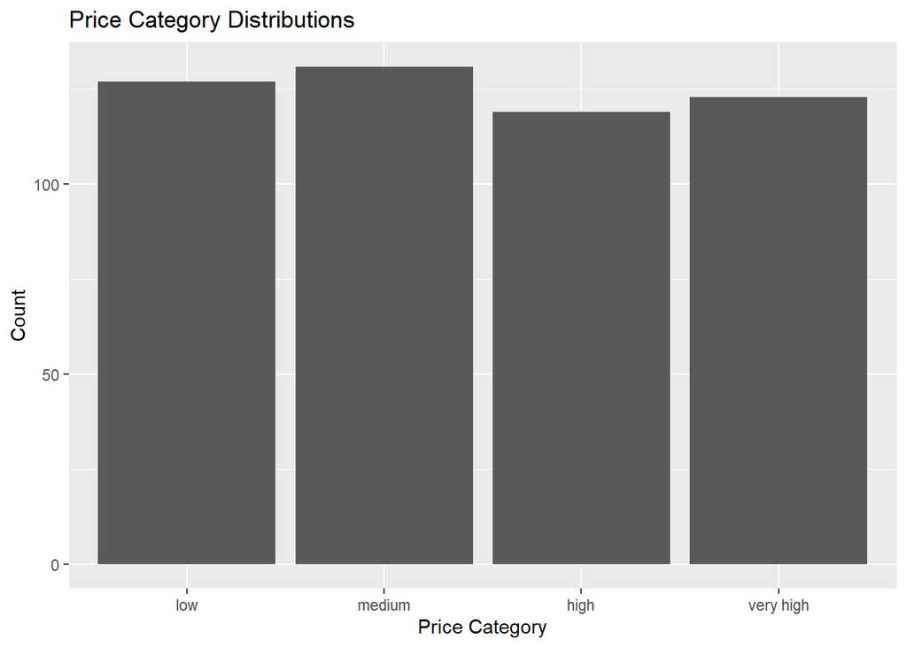

```r
# All checks seem right, let's see if our distribution checks out:
airbnb_clean$price_category = factor(price_category, levels = c("low", "medium", "high", "very high"))
ggplot(airbnb_clean, aes(price_category)) + geom_bar() + labs(x = "Price Category", y = "Count", title = "Price Category Distributions")
```

```r
# Looks reasonably even.
```

Maximum nights:

```r
summary_stats(airbnb_clean$maximum_nights)
```

```
## Total Count:  500
## N:  500
## Minimum:  3
## Maximum:  1125
## Mean:  736.986
## Standard Deviation:  518.5947
## Median:  1125
## Quantiles:
##   0%  25%  50%  75% 100%
##    3   30 1125 1125 1125
## IQR:  1095
```

Note the high proportion of 1125s, probably the maximum allowed for a listing by the website.

Reviews per month:

```r
summary_stats(airbnb_clean$reviews_per_month)
```

```
## Total Count:  500
## N:  426
## Minimum:  0.05
## Maximum:  9.75
## Mean:  2.135563
## Standard Deviation:  1.960553
## Median:  1.485
## Quantiles:
##    0%   25%   50%   75%  100%
## 0.050 0.620 1.485 3.245 9.750
## IQR:  2.625
```

This gives an interesting variety, let’s look at a histogram.

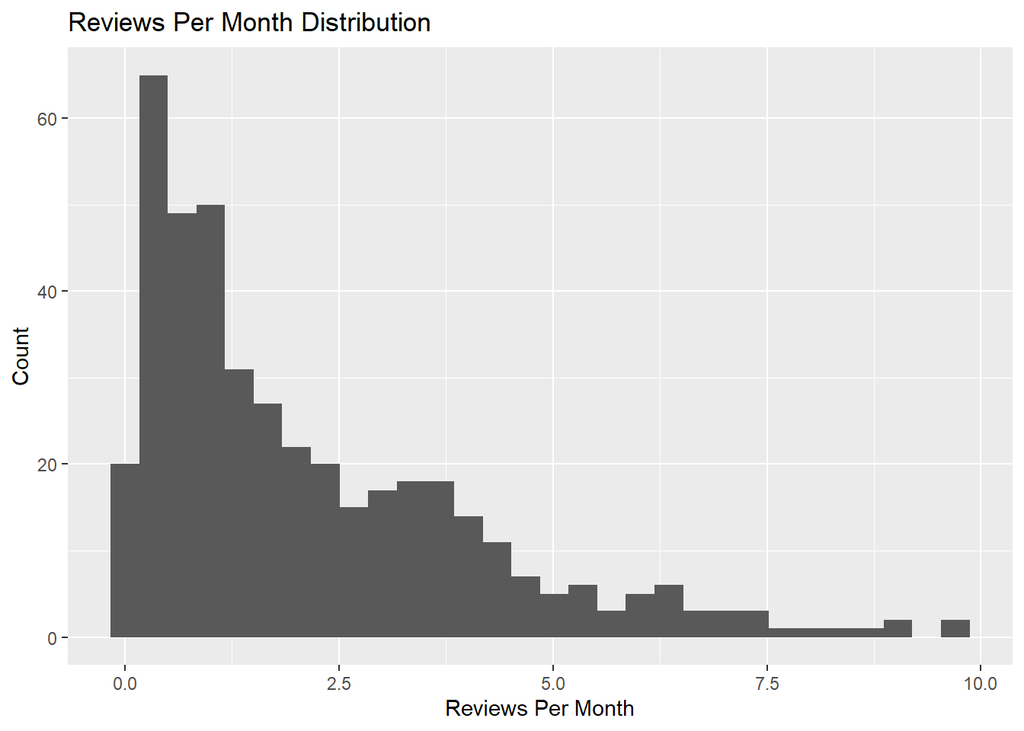

```r
ggplot(airbnb_clean, aes(reviews_per_month)) + geom_histogram() + labs(x = "Reviews Per Month", y = "Count", title = "Reviews Per Month Distribution")
```

We can see a right skew with a floor at 0, so we know most locations aren’t reviewed many times per month.

Cleanliness review score (out of 10):

```r
summary_stats(airbnb_clean$review_scores_cleanliness)
```

```
## Total Count:  500
## N:  425
## Minimum:  4
## Maximum:  10
## Mean:  9.477647
## Standard Deviation:  0.8467998
## Median:  10
## Quantiles:
##   0%  25%  50%  75% 100%
##    4    9   10   10   10
## IQR:  1
```

Communication review score (out of 10):

```r
summary_stats(airbnb_clean$review_scores_communication)
```

```
## Total Count:  500
## N:  424
## Minimum:  8
## Maximum:  10
## Mean:  9.856132
## Standard Deviation:  0.4016045
## Median:  10
## Quantiles:
##   0%  25%  50%  75% 100%
##    8   10   10   10   10
## IQR:  0
```

Value review score (out of 10):

```r
summary_stats(airbnb_clean$review_scores_value)
```

```
## Total Count:  500
## N:  422
## Minimum:  6
## Maximum:  10
## Mean:  9.56872
## Standard Deviation:  0.6673718
## Median:  10
## Quantiles:
##   0%  25%  50%  75% 100%
##    6    9   10   10   10
## IQR:  1
```

Seems like both review categories seem to tend toward the high end. A left skew is likely. Let’s check:

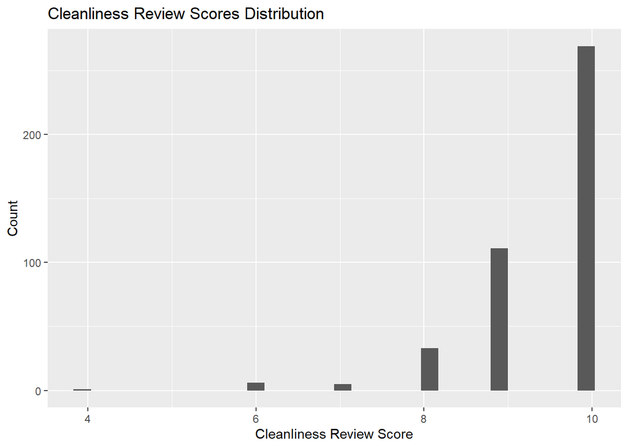

```r
ggplot(airbnb_clean, aes(review_scores_cleanliness)) + geom_histogram() + labs(x = "Cleanliness Review Score", y = "Count", title = "Cleanliness Review Scores Distribution")
```

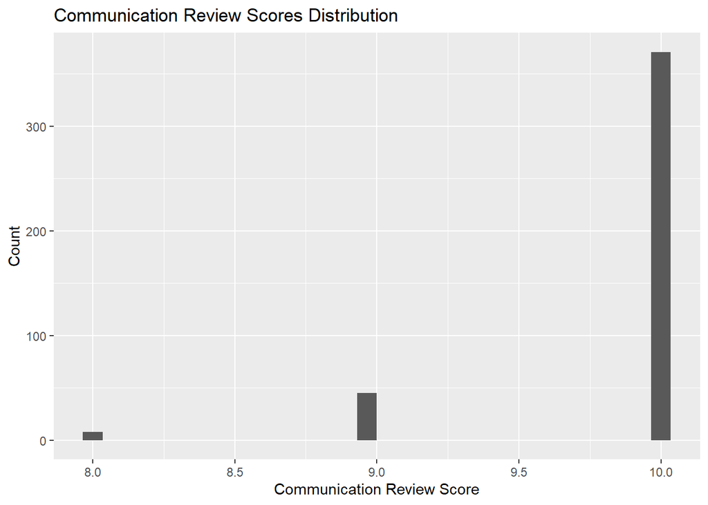

```r
ggplot(airbnb_clean, aes(review_scores_communication)) + geom_histogram() + labs(x = "Communication Review Score", y = "Count", title = "Communication Review Scores Distribution")
```

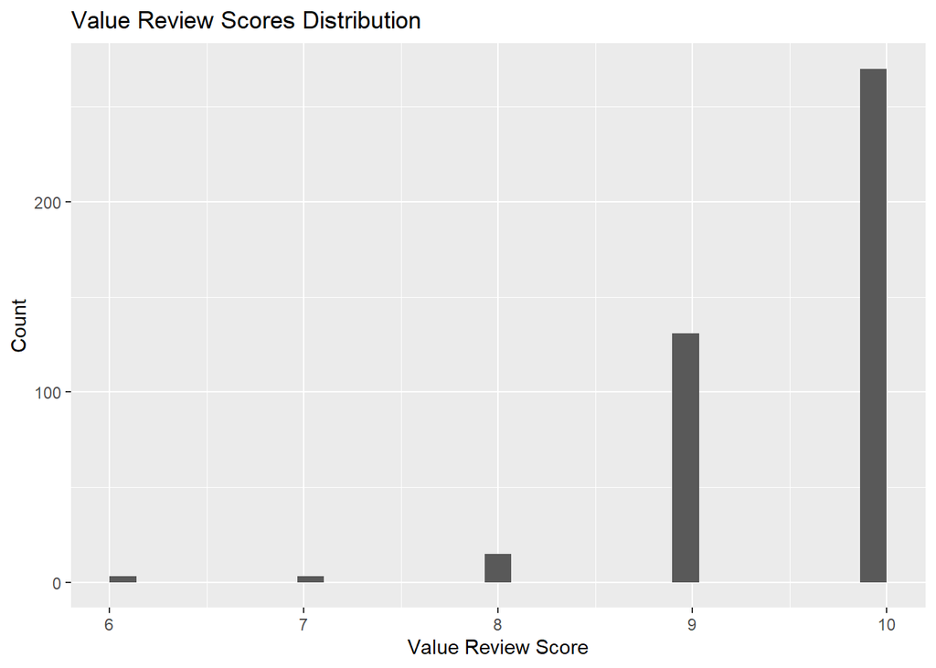

```r
ggplot(airbnb_clean, aes(review_scores_value)) + geom_histogram() + labs(x = "Value Review Score", y = "Count", title = "Value Review Scores Distribution")
```

Unsurprising. People tend to give high reviews in the dataset.

```r
# Let's look at some counts for factors to gauge their plottability
# Unique host names:
length(unique(airbnb_clean$host_name))
```

```
## [1] 365
```

```r
# Unique host locations:
length(unique(airbnb_clean$host_location))
```

```
## [1] 31
```

```r
# Unique host neighborhoods:
length(unique(airbnb_clean$host_neighbourhood))
```

```
## [1] 61
```

```r
# Unique listing neighborhoods:
length(unique(airbnb_clean$neighbourhood))
```

```
## [1] 45
```

```r
# Unique room types:
length(unique(airbnb_clean$room_type))
```

```
## [1] 3
```

```r
# Unique bed types:
length(unique(airbnb_clean$bed_type))
```

```
## [1] 5
```

We can see that some variables have more values than are comfortably put into a bar graph, but we easily look at distributions for room and bed types.

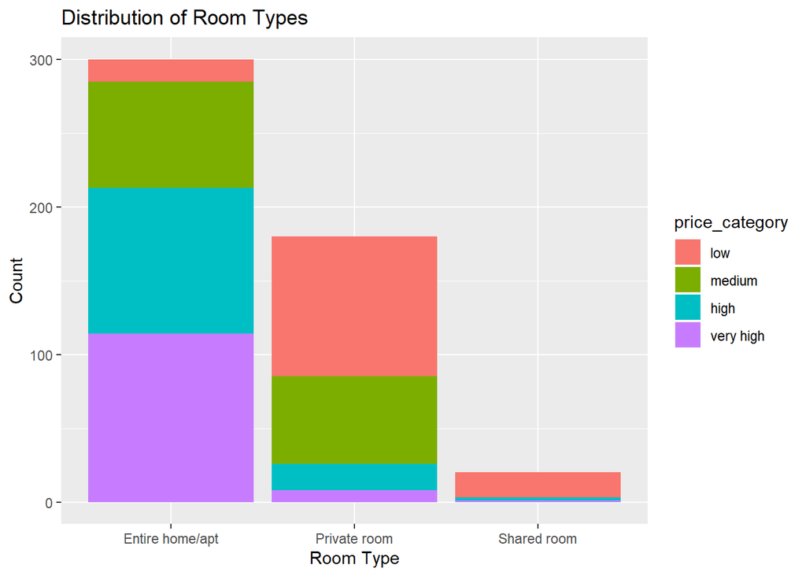

```r
ggplot(airbnb_clean, aes(room_type, fill = price_category)) + geom_bar() + labs(x = "Room Type", y = "Count", title = "Distribution of Room Types")
```

So, we can see that most rooms are an entire home or apartment, many are private rooms, and very few are shared rooms. Note that the majority of high and very high prices appear in the entire home category, unsurprisingly. Most low prices are in the private room category. While private rooms are not the least luxurious, they are much more common than shared rooms, which have a much higher proportion of low prices within its room category. In summary, higher price means more private space.

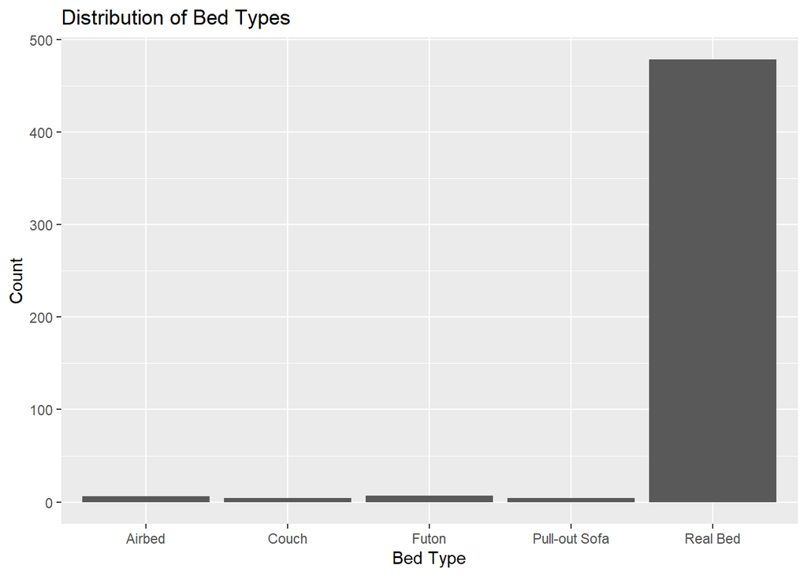

```r
ggplot(airbnb_clean, aes(bed_type)) + geom_bar() + labs(x = "Bed Type", y = "Count", title = "Distribution of Bed Types")
```

The overwhelming majority of beds are real beds, with very few out of the 500 total listings in the data set being airbeds, couches, futons, or pull-out sofas.

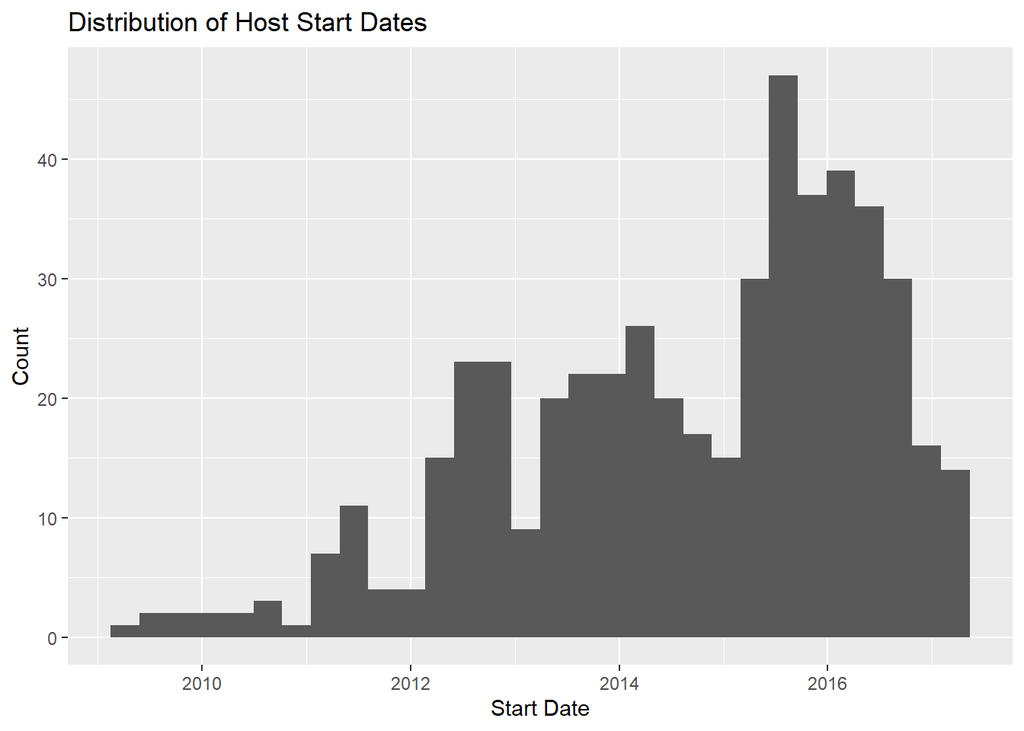

```r
# How about distributions of host start times?
ggplot(airbnb_clean, aes(host_since)) + geom_histogram() + labs(x = "Start Date", y = "Count", title = "Distribution of Host Start Dates")
```

We have a left skewed distribution, meaning in this context that more currently active hosts started more recently than not. Ie, there has likely either been a sharp rise in hosts in the area over time or hosts tend to host for a short amount of time before quitting, leading to the active hosts beginning more recently. The former is more obvious, but we would need data about inactive hosts to rule out the latter.

## Host Data

Let’s look at some data involving individual hosts.

```r
# A count of unique host id's will tell us how many hosts we have
print(length(unique(airbnb_clean$host_id)))
```

```
## [1] 461
```

```r
# Out of curiosity, does this match the unique host names?
print(length(unique(airbnb_clean$host_name)))
```

```
## [1] 365
```

So, it seems at least one host (almost certainly more) has multiple listings available, given that our dataset has 500 listings. Also, hosts share names.

What are some common names?

```r
repeat_names = (sort(table(airbnb_clean$host_name), decreasing = TRUE))
repeat_names[repeat_names > 1]
```

```
##
##           Joe        Sonder          John          Paul        Justin
##            10             9             7             7             6
##          Nick       Michael         Chris         David       Jessica
##             6             5             4             4             4
##         Laura          Lisa           Liz          Mark          Matt
##             4             4             4             4             4
##          Mike     The Flats        Amanda       Charles           Dan
##             4             4             3             3             3
##        Daniel      Freehand         James      Jennifer         Maria
##             3             3             3             3             3
##         Mario        Nicole         Sarah        Sharon     Stephanie
##             3             3             3             3             3
##           Tom           Ami        Andrew        Ashley   At Home Inn
##             3             2             2             2             2
##     Catherine   Christopher          Dana         Emily         Frank
##             2             2             2             2             2
##          Jane          Jeff         Jenny         Jimmy          Kari
##             2             2             2             2             2
##          Kate           Kim        Kristi          Leon       Liliana
##             2             2             2             2             2
##          Lori          Mary         Megan     Mejai Kai Melanie & Joe
##             2             2             2             2             2
##        Monica       Natalia        Pamela         Peter       Rebecca
##             2             2             2             2             2
##          Ross         Steve         Terry        Thomas        Trevor
##             2             2             2             2             2
```

Some of these are obviously common names, eg Joe, John, Paul. Some seem to be a single business with multiple properties, like “At Home Inn” and “The Flats”. Similarly, we find that our second most common host name, “Sonder”, is also such a business with a bit of research.

Let’s look at ratings by name

```r
# First, we make a total rating by adding the three rating types
airbnb_clean = airbnb_clean %>% mutate(review_scores_total = (review_scores_communication + review_scores_cleanliness + review_scores_value))
avg_score_by_name = airbnb_clean %>% group_by(host_name) %>% summarize(avg = mean(review_scores_total))
avg_score_by_name = na.omit(avg_score_by_name)
avg_score_by_name = avg_score_by_name %>% arrange(desc(avg))
head(avg_score_by_name, 15)
```

```
## # A tibble: 15 x 2
##    host_name     avg
##    <fct>       <dbl>
##  1 Adi            30
##  2 Alan           30
##  3 Alex           30
##  4 Alexander      30
##  5 Ali            30
##  6 Alissa         30
##  7 Amber          30
##  8 Amrit Rania    30
##  9 Amy            30
## 10 Andy           30
## 11 Anjli          30
## 12 Anna-Lisa      30
## 13 Anne           30
## 14 Anne-Marie     30
## 15 April          30
```

We can see have a lot of 30/30 for total scores, meaning many people got very good ratings as mentioned earlier. Unique, however, are low scores. Let’s look at the bottom three.

```r
tail(avg_score_by_name, 3)
```

```
## # A tibble: 3 x 2
##   host_name   avg
##   <fct>     <dbl>
## 1 Wilson       22
## 2 Niki         20
## 3 Sam          18
```

Since these three scores are unique, we can use them as keys for finding more info on the users. Had we used host_id, we could have used that as well, but here we used names for the sake of readability.

```r
sam = airbnb_clean %>% filter(review_scores_total == 18 & host_name == "Sam")
niki = airbnb_clean %>% filter(review_scores_total == 20 & host_name == "Niki")
wilson = airbnb_clean %>% filter(review_scores_total == 22 & host_name == "Wilson")
```

We can get a quick data frame of our three hosts of interest with host relevant data.

```r
low_rated = rbind(sam, niki, wilson)
```

Let’s look at their ratings.

```r
# Note: 49, 50, 51 are the review score columns, 15 is host name
low_rated[,c(15, 49:51)]
```

```
##   host_name review_scores_cleanliness review_scores_communication
## 1       Sam                         4                           8
## 2      Niki                         6                           8
## 3    Wilson                         6                           8
##   review_scores_value
## 1                   6
## 2                   6
## 3                   8
```

So, it seems that having good communication all around, the hosts have average to good value scores and poor to average cleanliness, their weakest factor in general. Let’s see how cleanliness generally compares to other review scores across all hosts.

```r
avg_scores_by_name = airbnb_clean %>% group_by(host_name) %>% summarize(avg_cl = mean(review_scores_cleanliness), avg_com = mean(review_scores_communication), avg_val = mean(review_scores_value) , avg_total = mean(review_scores_total))
avg_scores_by_name = na.omit(avg_scores_by_name)
```

Now, we can look at summary stats of each rating variable

Cleanliness:

```r
summary_stats(avg_scores_by_name$avg_cl)
```

```
## Total Count:  292
## N:  292
## Minimum:  4
## Maximum:  10
## Mean:  9.477645
## Standard Deviation:  0.8622203
## Median:  10
## Quantiles:
##   0%  25%  50%  75% 100%
##    4    9   10   10   10
## IQR:  1
```

Communication:

```r
summary_stats(avg_scores_by_name$avg_com)
```

```
## Total Count:  292
## N:  292
## Minimum:  8
## Maximum:  10
## Mean:  9.860826
## Standard Deviation:  0.3800228
## Median:  10
## Quantiles:
##   0%  25%  50%  75% 100%
##    8   10   10   10   10
## IQR:  0
```

Value:

```r
summary_stats(avg_scores_by_name$avg_val)
```

```
## Total Count:  292
## N:  292
## Minimum:  6
## Maximum:  10
## Mean:  9.585331
## Standard Deviation:  0.6301351
## Median:  10
## Quantiles:
##   0%  25%  50%  75% 100%
##    6    9   10   10   10
## IQR:  1
```

We can see that thought our base review scores don’t vary too much in mean, cleanliness has the lowest mean (~9.48), the lowest minimum (4), and the highest standard deviation (~0.862). So, there does seem to be a bit of a lower lump in the tail of our distribution (which we saw in the histograms above). Let’s see how many 4s we actually have.

```r
sum(na.omit(airbnb_clean$review_scores_cleanliness) == 4)
```

```
## [1] 1
```